# Moringa_School_IP_Wk13_Mutura_Kuria

Mutura Kuria

1/29/2022

```r
# Loading Libraries necessary

library(tidyverse)
library(magrittr)
```

```r
library(warn = -1)

library(RColorBrewer)
library(ggplot2)
library(lattice)
library(corrplot)
library(DataExplorer)
library(Hmisc)
library(pastecs)
library(psych)
library(factoextra)
library(Rtsne)
library(caret)
```

# 1. Problem Definition

Kira Plastinina is a Russian brand that is sold through a defunct chain of retail stores in Russia, Ukraine, Kazakhstan, Belarus, China, Philippines, and Armenia. The brand’s Sales and Marketing team would like to understand their customer’s behavior from data that they have collected over the past year. More specifically, they would like to learn the characteristics of customer groups.

-Perform clustering stating insights drawn from your analysis and visualizations. -Upon implementation, provide comparisons between the approaches learned this week i.e. K-Means clustering vs Hierarchical clustering highlighting the strengths and limitations of each approach in the context of your analysis.

# 2. Data Sourcing

- The data is sourced from this link (http://bit.ly/EcommerceCustomersDataset)

## 2.1 Loading the dataset

```r
#Loading the data
df <-read.csv("http://bit.ly/EcommerceCustomersDataset", header = TRUE)
#Showing head of data
head(df)
```

```
##   Administrative Administrative_Duration Informational Informational_Duration
## 1              0                       0             0                      0
## 2              0                       0             0                      0
## 3              0                      -1             0                     -1
## 4              0                       0             0                      0
## 5              0                       0             0                      0
## 6              0                       0             0                      0
##   ProductRelated ProductRelated_Duration BounceRates ExitRates PageValues
## 1              1                0.000000  0.20000000 0.2000000          0
## 2              2               64.000000  0.00000000 0.1000000          0
## 3              1               -1.000000  0.20000000 0.2000000          0
## 4              2                2.666667  0.05000000 0.1400000          0
## 5             10              627.500000  0.02000000 0.0500000          0
## 6             19              154.216667  0.01578947 0.0245614          0
##   SpecialDay Month OperatingSystems Browser Region TrafficType
## 1          0   Feb                1       1      1           1
## 2          0   Feb                2       2      1           2
## 3          0   Feb                4       1      9           3
## 4          0   Feb                3       2      2           4
## 5          0   Feb                3       3      1           4
## 6          0   Feb                2       2      1           3
##         VisitorType Weekend Revenue
## 1 Returning_Visitor   FALSE   FALSE
## 2 Returning_Visitor   FALSE   FALSE
## 3 Returning_Visitor   FALSE   FALSE
## 4 Returning_Visitor   FALSE   FALSE
## 5 Returning_Visitor    TRUE   FALSE
## 6 Returning_Visitor   FALSE   FALSE
```

# 3. Check the Data

```r
#Checking for dimensions and class types
str(df)
```

```
## 'data.frame':    12330 obs. of  18 variables:
##  $ Administrative         : int  0 0 0 0 0 0 0 1 0 0 ...
##  $ Administrative_Duration: num  0 0 -1 0 0 0 -1 -1 0 0 ...
##  $ Informational          : int  0 0 0 0 0 0 0 0 0 0 ...
##  $ Informational_Duration : num  0 0 -1 0 0 0 -1 -1 0 0 ...
##  $ ProductRelated         : int  1 2 1 2 10 19 1 1 2 3 ...
##  $ ProductRelated_Duration: num  0 64 -1 2.67 627.5 ...
##  $ BounceRates            : num  0.2 0 0.2 0.05 0.02 ...
##  $ ExitRates              : num  0.2 0.1 0.2 0.14 0.05 ...
##  $ PageValues             : num  0 0 0 0 0 0 0 0 0 0 ...
##  $ SpecialDay             : num  0 0 0 0 0 0 0.4 0 0.8 0.4 ...
##  $ Month                  : chr  "Feb" "Feb" "Feb" "Feb" ...
##  $ OperatingSystems       : int  1 2 4 3 3 2 2 1 2 2 ...
##  $ Browser                : int  1 2 1 2 3 2 4 2 2 4 ...
##  $ Region                 : int  1 1 9 2 1 1 3 1 2 1 ...
##  $ TrafficType            : int  1 2 3 4 4 3 3 5 3 2 ...
##  $ VisitorType            : chr  "Returning_Visitor" "Returning_Visitor" "Returning_Visitor" "Returning_Visitor" ...
##  $ Weekend                : logi  FALSE FALSE FALSE FALSE TRUE FALSE ...
##  $ Revenue                : logi  FALSE FALSE FALSE FALSE FALSE FALSE ...
```

```r
summary((df))
```

```
##  Administrative   Administrative_Duration Informational
##  Min.   : 0.000   Min.   :  -1.00         Min.   : 0.000
##  1st Qu.: 0.000   1st Qu.:   0.00         1st Qu.: 0.000
##  Median : 1.000   Median :   8.00         Median : 0.000
##  Mean   : 2.318   Mean   :  80.91         Mean   : 0.504
##  3rd Qu.: 4.000   3rd Qu.:  93.50         3rd Qu.: 0.000
##  Max.   :27.000   Max.   :3398.75         Max.   :24.000
##  NA's   :14       NA's   :14              NA's   :14
##  Informational_Duration ProductRelated   ProductRelated_Duration
##  Min.   :  -1.00        Min.   :  0.00   Min.   :   -1.0
##  1st Qu.:   0.00        1st Qu.:  7.00   1st Qu.:  185.0
##  Median :   0.00        Median : 18.00   Median :  599.8
##  Mean   :  34.51        Mean   : 31.76   Mean   : 1196.0
##  3rd Qu.:   0.00        3rd Qu.: 38.00   3rd Qu.: 1466.5
##  Max.   :2549.38        Max.   :705.00   Max.   :63973.5
##  NA's   :14             NA's   :14       NA's   :14
##   BounceRates         ExitRates         PageValues        SpecialDay
##  Min.   :0.000000   Min.   :0.00000   Min.   :  0.000   Min.   :0.00000
##  1st Qu.:0.000000   1st Qu.:0.01429   1st Qu.:  0.000   1st Qu.:0.00000
##  Median :0.003119   Median :0.02512   Median :  0.000   Median :0.00000
##  Mean   :0.022152   Mean   :0.04300   Mean   :  5.889   Mean   :0.06143
##  3rd Qu.:0.016684   3rd Qu.:0.05000   3rd Qu.:  0.000   3rd Qu.:0.00000
##  Max.   :0.200000   Max.   :0.20000   Max.   :361.764   Max.   :1.00000
##  NA's   :14         NA's   :14
##     Month           OperatingSystems    Browser           Region
##  Length:12330       Min.   :1.000    Min.   : 1.000   Min.   :1.000
##  Class :character   1st Qu.:2.000    1st Qu.: 2.000   1st Qu.:1.000
##  Mode  :character   Median :2.000    Median : 2.000   Median :3.000
##                     Mean   :2.124    Mean   : 2.357   Mean   :3.147
##                     3rd Qu.:3.000    3rd Qu.: 2.000   3rd Qu.:4.000
##                     Max.   :8.000    Max.   :13.000   Max.   :9.000
##
##   TrafficType    VisitorType         Weekend         Revenue
##  Min.   : 1.00   Length:12330       Mode :logical   Mode :logical
##  1st Qu.: 2.00   Class :character   FALSE:9462      FALSE:10422
##  Median : 2.00   Mode  :character   TRUE :2868      TRUE :1908
##  Mean   : 4.07
##  3rd Qu.: 4.00
##  Max.   :20.00
##
```

-The dataset consists of 10 numerical and 8 categorical attributes. The ‘Revenue’ attribute can be used as the class label. -Data has 12330 observations(rows) and 18 variables(columns) We have integers, numerics , character and logical features in our dataset.

# 4. Perform Data Cleaning

```r
# conversion from just a raw dataset to a dataframe
df = as.data.frame(df)

# Cleaning column names, by making them uniform
colnames(df) = tolower(colnames(df))
```

## 4.1.1 Duplicated values

```r
#Checking for duplicated rows
duplicated_rows <- df[duplicated(df),]
dim(duplicated_rows)
```

```
## [1] 119  18
```

```r
#Dropping duplicated rows
df <- df[!duplicated(df), ]
dim(df)
```

```
## [1] 12211    18
```

## 4.1.2 Missing Values

```r
# Checking for Missing Values

colSums(is.na(df))
```

```
##          administrative administrative_duration           informational
##                      12                      12                      12
##  informational_duration          productrelated productrelated_duration
##                      12                      12                      12
##             bouncerates               exitrates              pagevalues
##                      12                      12                       0
##              specialday                   month        operatingsystems
##                       0                       0                       0
##                 browser                  region             traffictype
##                       0                       0                       0
##             visitortype                 weekend                 revenue
##                       0                       0                       0
```

```r
# Filling the missing values using the mutate function and pipe operator
# Each column will be filled with its own mean

df  = df %>%

    mutate(administrative =replace(administrative,is.na(administrative),mean(administrative,na.rm=TRUE)))%>%
    mutate(administrative_duration =replace(administrative_duration,is.na(administrative_duration),mean(administrative_duration,na.rm=TRUE)))%>%
    mutate(informational = replace(informational, is.na(informational), mean(informational, na.rm = TRUE)))%>%
    mutate(informational_duration =replace(informational_duration,is.na(informational_duration),mean(informational_duration,na.rm=TRUE)))%>%
    mutate(productrelated =replace(productrelated,is.na(productrelated),mean(productrelated,na.rm=TRUE)))%>%
    mutate(productrelated_duration = replace(productrelated_duration, is.na(productrelated_duration), mean(productrelated_duration, na.rm = TRUE)))%>%
    mutate(bouncerates =replace(bouncerates, is.na(bouncerates),mean(bouncerates,na.rm=TRUE)))%>%
    mutate(exitrates = replace(exitrates, is.na(exitrates), mean(exitrates, na.rm = TRUE)))
```

```r
colSums(is.na(df))
```

```
##          administrative administrative_duration           informational
##                       0                       0                       0
##  informational_duration          productrelated productrelated_duration
##                       0                       0                       0
##             bouncerates               exitrates              pagevalues
##                       0                       0                       0
##              specialday                   month        operatingsystems
##                       0                       0                       0
##                 browser                  region             traffictype
##                       0                       0                       0
##             visitortype                 weekend                 revenue
##                       0                       0                       0
```

All missing values have been filled

```r
cat_cols = c('month', 'operatingsystems',   'browser',  'region',   'traffictype', 'visitortype')

# Changing columns to factors
df[,cat_cols] %<>% lapply(function(x) as.factor(as.character(x)))
str(df)
```

```
## 'data.frame':    12211 obs. of  18 variables:
##  $ administrative         : num  0 0 0 0 0 0 0 1 0 0 ...
##  $ administrative_duration: num  0 0 -1 0 0 0 -1 -1 0 0 ...
##  $ informational          : num  0 0 0 0 0 0 0 0 0 0 ...
##  $ informational_duration : num  0 0 -1 0 0 0 -1 -1 0 0 ...
##  $ productrelated         : num  1 2 1 2 10 19 1 1 2 3 ...
##  $ productrelated_duration: num  0 64 -1 2.67 627.5 ...
##  $ bouncerates            : num  0.2 0 0.2 0.05 0.02 ...
##  $ exitrates              : num  0.2 0.1 0.2 0.14 0.05 ...
##  $ pagevalues             : num  0 0 0 0 0 0 0 0 0 0 ...
##  $ specialday             : num  0 0 0 0 0 0 0.4 0 0.8 0.4 ...
##  $ month                  : Factor w/ 10 levels "Aug","Dec","Feb",..: 3 3 3 3 3 3 3 3 3 3 ...
##  $ operatingsystems       : Factor w/ 8 levels "1","2","3","4",..: 1 2 4 3 3 2 2 1 2 2 ...
##  $ browser                : Factor w/ 13 levels "1","10","11",..: 1 6 1 6 7 6 8 6 6 8 ...
##  $ region                 : Factor w/ 9 levels "1","2","3","4",..: 1 1 9 2 1 1 3 1 2 1 ...
##  $ traffictype            : Factor w/ 20 levels "1","10","11",..: 1 12 14 15 15 14 14 16 14 12 ...
##  $ visitortype            : Factor w/ 3 levels "New_Visitor",..: 3 3 3 3 3 3 3 3 3 3 ...
##  $ weekend                : logi  FALSE FALSE FALSE FALSE TRUE FALSE ...
##  $ revenue                : logi  FALSE FALSE FALSE FALSE FALSE FALSE ...
```

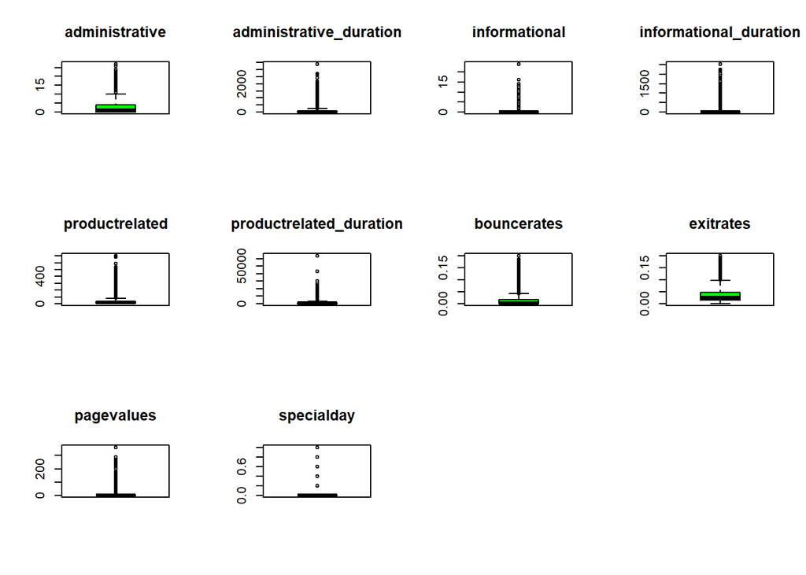

```r
#Checking for outliers
# Creating separate boxplots for each attribute
par(mfrow=c(3,4))
for(i in 1:10) {
    boxplot(df[,i], main=names(df)[i], col = "green")}
```

There are outliers on almost all the columns. The outliers are a reflection of the kind of data that is the retail clients data and therefore its normal

# 5. Perform Exploratory Data Analysis (Univariate, Bivariate & Multivariate)

## 5.1 Univariate Analysis

### 5.1.1 Measures of central tendancy(Mean, Median, Mode), dispersion (Min, Max, Range, Quartiles, Variance, Standard deviation), others(Skewness, Kurtosis)

```r
#Lets select the numeric variables
nums <- subset(df, select = -c(specialday, month, operatingsystems,browser, region, traffictype, visitortype,weekend,revenue))
head(nums)
```

```
##   administrative administrative_duration informational informational_duration
## 1              0                       0             0                      0
## 2              0                       0             0                      0
## 3              0                      -1             0                     -1
## 4              0                       0             0                      0
## 5              0                       0             0                      0
## 6              0                       0             0                      0
##   productrelated productrelated_duration bouncerates exitrates pagevalues
## 1              1                0.000000  0.20000000 0.2000000          0
## 2              2               64.000000  0.00000000 0.1000000          0
## 3              1               -1.000000  0.20000000 0.2000000          0
## 4              2                2.666667  0.05000000 0.1400000          0
## 5             10              627.500000  0.02000000 0.0500000          0
## 6             19              154.216667  0.01578947 0.0245614          0
```

```r
install.packages("pastecs")
library(pastecs)
```

```r
# Using the pastecs library we summeraze all the numeric variables we separated above
stat.desc(nums)
```

```
##              administrative administrative_duration informational
## nbr.val        1.221100e+04            12211.000000  1.221100e+04
## nbr.null       5.637000e+03             5740.000000  9.569000e+03
## nbr.na         0.000000e+00                0.000000  0.000000e+00
## min            0.000000e+00               -1.000000  0.000000e+00
## max            2.700000e+01             3398.750000  2.400000e+01
## range          2.700000e+01             3399.750000  2.400000e+01
## sum            2.857408e+04           997420.653671  6.213106e+03
## median         1.000000e+00                9.000000  0.000000e+00
## mean           2.340028e+00               81.682143  5.088122e-01
## SE.mean        3.012771e-02                1.605751  1.153983e-02
## CI.mean.0.95   5.905508e-02                3.147526  2.261989e-02
## var            1.108367e+01            31485.276158  1.626110e+00
## std.dev        3.329214e+00              177.440909  1.275190e+00
## coef.var       1.422724e+00                2.172334  2.506210e+00
##              informational_duration productrelated productrelated_duration
## nbr.val                12211.000000   1.221100e+04            1.221100e+04
## nbr.null                9762.000000   3.500000e+01            6.020000e+02
## nbr.na                     0.000000   0.000000e+00            0.000000e+00
## min                       -1.000000   0.000000e+00           -1.000000e+00
## max                     2549.375000   7.050000e+02            6.397352e+04
## range                   2550.375000   7.050000e+02            6.397452e+04
## sum                   425398.714485   3.914657e+05            1.474488e+07
## median                     0.000000   1.800000e+01            6.110000e+02
## mean                      34.837336   3.205845e+01            1.207508e+03
## SE.mean                    1.279499   4.034174e-01            1.736584e+01
## CI.mean.0.95               2.508020   7.907619e-01            3.403979e+01
## var                    19990.840518   1.987286e+03            3.682499e+06
## std.dev                  141.388969   4.457899e+01            1.918984e+03
## coef.var                   4.058547   1.390554e+00            1.589210e+00
##               bouncerates    exitrates   pagevalues
## nbr.val      1.221100e+04 1.221100e+04 1.221100e+04
## nbr.null     5.510000e+03 7.600000e+01 9.481000e+03
## nbr.na       0.000000e+00 0.000000e+00 0.000000e+00
## min          0.000000e+00 0.000000e+00 0.000000e+00
## max          2.000000e-01 2.000000e-01 3.617637e+02
## range        2.000000e-01 2.000000e-01 3.617637e+02
## sum          2.496751e+02 5.067172e+02 7.261455e+04
## median       2.941176e-03 2.500000e-02 0.000000e+00
## mean         2.044674e-02 4.149678e-02 5.946651e+00
## SE.mean      4.106678e-04 4.183078e-04 1.687691e-01
## CI.mean.0.95 8.049739e-04 8.199495e-04 3.308141e-01
## var          2.059361e-03 2.136698e-03 3.478058e+02
## std.dev      4.538019e-02 4.622443e-02 1.864955e+01
## coef.var     2.219434e+00 1.113928e+00 3.136144e+00
```

```r
install.packages("Hmisc")
library(Hmisc)
```

```r
# Using the describe() function which is part of the Hmisc package displays the following additional statistics: like skewness and kurtosis
describe(nums)
```

```
##                         vars     n    mean      sd median trimmed    mad min
## administrative             1 12211    2.34    3.33   1.00    1.66   1.48   0
## administrative_duration    2 12211   81.68  177.44   9.00   42.89  13.34  -1
## informational              3 12211    0.51    1.28   0.00    0.18   0.00   0
## informational_duration     4 12211   34.84  141.39   0.00    3.75   0.00  -1
## productrelated             5 12211   32.06   44.58  18.00   23.06  19.27   0
## productrelated_duration    6 12211 1207.51 1918.98 611.00  832.56 747.53  -1
## bouncerates                7 12211    0.02    0.05   0.00    0.01   0.00   0
## exitrates                  8 12211    0.04    0.05   0.03    0.03   0.02   0
## pagevalues                 9 12211    5.95   18.65   0.00    1.33   0.00   0
##                              max    range skew kurtosis    se
## administrative             27.00    27.00 1.95     4.64  0.03
## administrative_duration  3398.75  3399.75 5.59    50.14  1.61
## informational              24.00    24.00 4.01    26.67  0.01
## informational_duration   2549.38  2550.38 7.54    75.53  1.28
## productrelated            705.00   705.00 4.33    31.08  0.40
## productrelated_duration 63973.52 63974.52 7.25   136.71 17.37
## bouncerates                 0.20     0.20 3.15     9.27  0.00
## exitrates                   0.20     0.20 2.23     4.63  0.00
## pagevalues                361.76   361.76 6.35    64.99  0.17
```

### 5.2 Visualizations

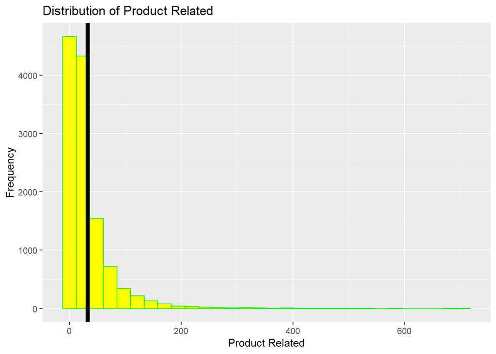

```r
# Plotting a histogram using ggplots
#
#

df %>%
    ggplot(aes(productrelated)) +
    geom_histogram(color = "Green",fill = "yellow") +
    geom_vline(xintercept = mean(df$productrelated), lwd = 2) +
    labs(title = "Distribution of Product Related",
         x = "Product Related",
         y = "Frequency")
```

Product Related is skewed to the right probably because of the outlies we saw earlier. Making it a good case to investigate further.

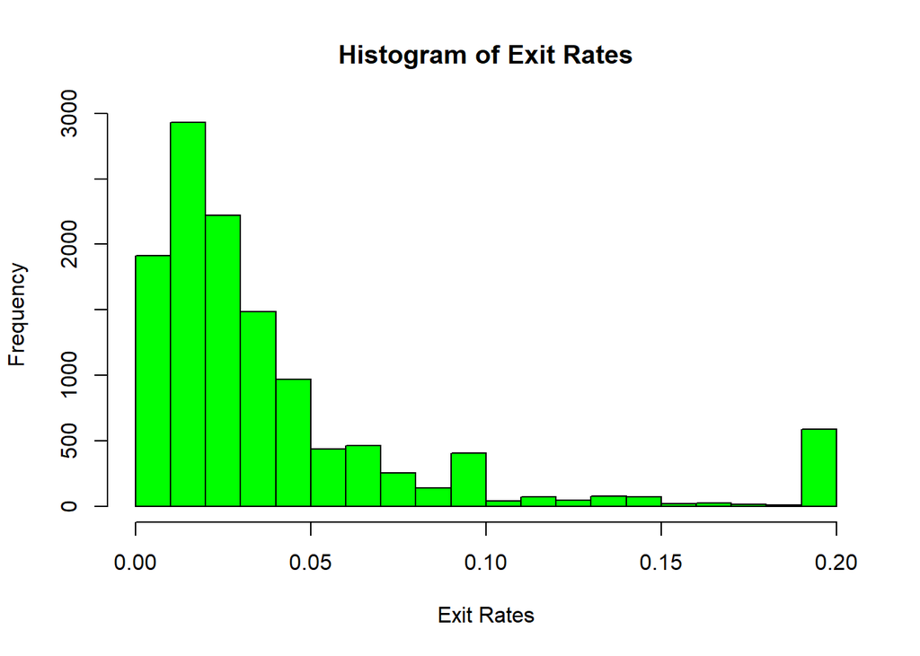

```r
# Histogram of Exit Rates

hist(df$exitrates,
     main = "Histogram of Exit Rates",
     xlab = "Exit Rates",
     col = "Green")
```

Another distribution that is right skewed

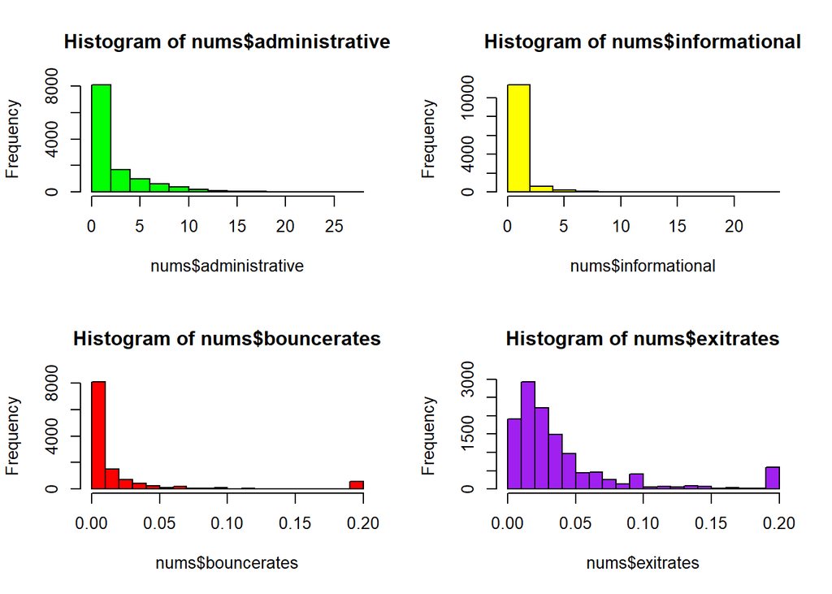

```r
#Plotting histograms to show distribution of variables
par(mfrow = c(2, 2))
hist(nums$administrative,col = "Green")
hist(nums$informational, col = "Yellow")
hist(nums$bouncerates,col = "Red")
hist(nums$exitrates,col = "Purple")
```

Most distributions are skewed towards the right.

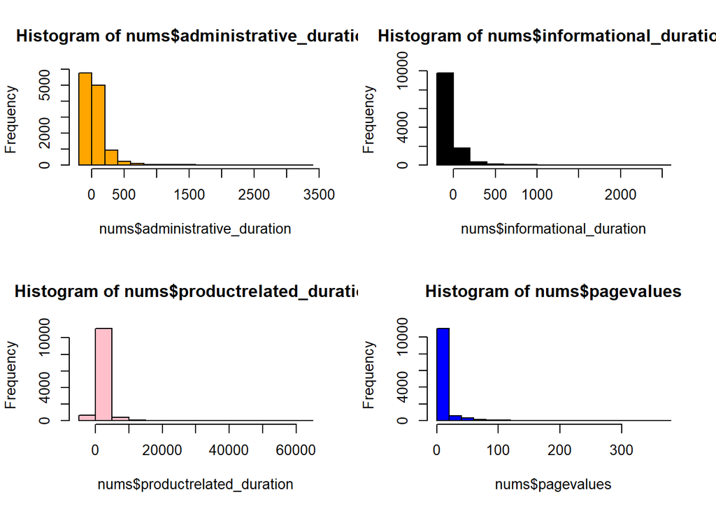

```r
par(mfrow = c(2, 2))
hist(nums$administrative_duration, ,col = "Orange")
hist(nums$informational_duration,col = "Black")
hist(nums$productrelated_duration,col = "Pink")
hist(nums$pagevalues,col = "Blue")
```

```r
#install.packages("ggpubr")
library(ggpubr)
```

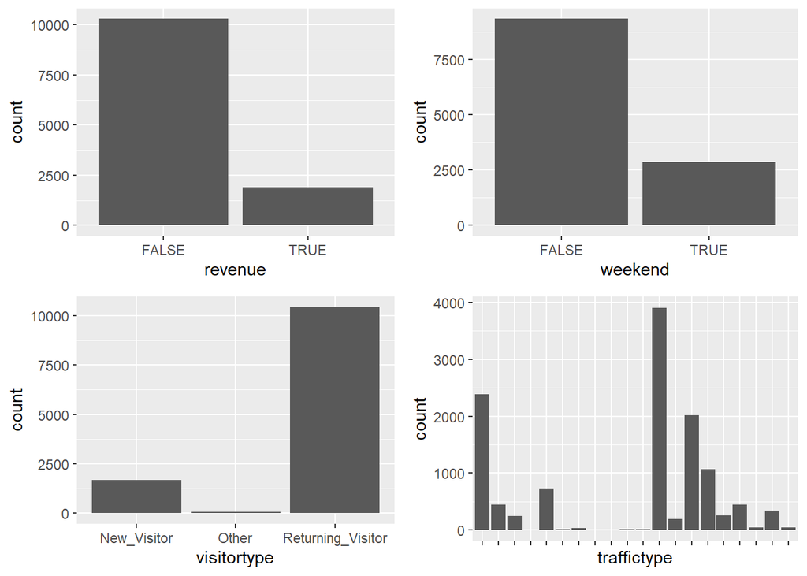

```r
#Traffic vs revenue?
r <- ggplot(data = df) +
  geom_bar(mapping = aes(x = revenue))
#Weekend traffic
w <- ggplot(data = df) +
  geom_bar(mapping = aes(x = weekend))
#Who frequented the website?
v <-ggplot(data = df) +
  geom_bar(mapping = aes(x = visitortype))
#Traffic type
t <- ggplot(data = df) +
  geom_bar(mapping = aes(x = traffictype))
ggarrange(r, w, v, t + rremove("x.text"),
          ncol = 2, nrow = 2)
```

- Most clicks did not generate revenue - Weekday visitors were many than weekend - Most visitors are returning

## 5.2 Bivariate Analysis

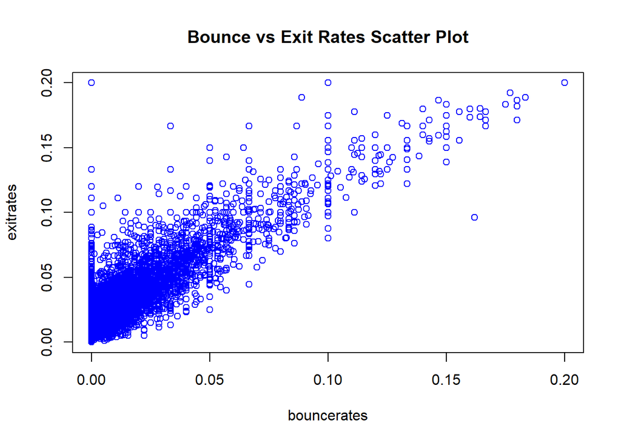

```r
# Plotting a scatter plot using the plot() method

plot(exitrates ~ bouncerates, dat = df,
      col = "Blue",
      main = "Bounce vs Exit Rates Scatter Plot")
```

-There exists strong positive correlation between Exit rates and Bounce rates.

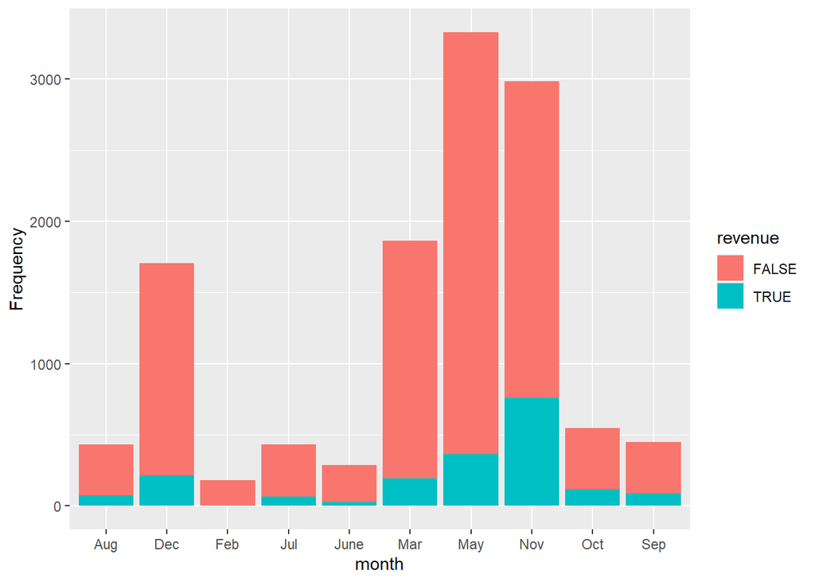

```r
#Revenue generation per month
df %>%
  ggplot() +
  aes(x = month, revenue = ..count../nrow(df), fill = revenue) +
  geom_bar() +
  ylab("Frequency")
```

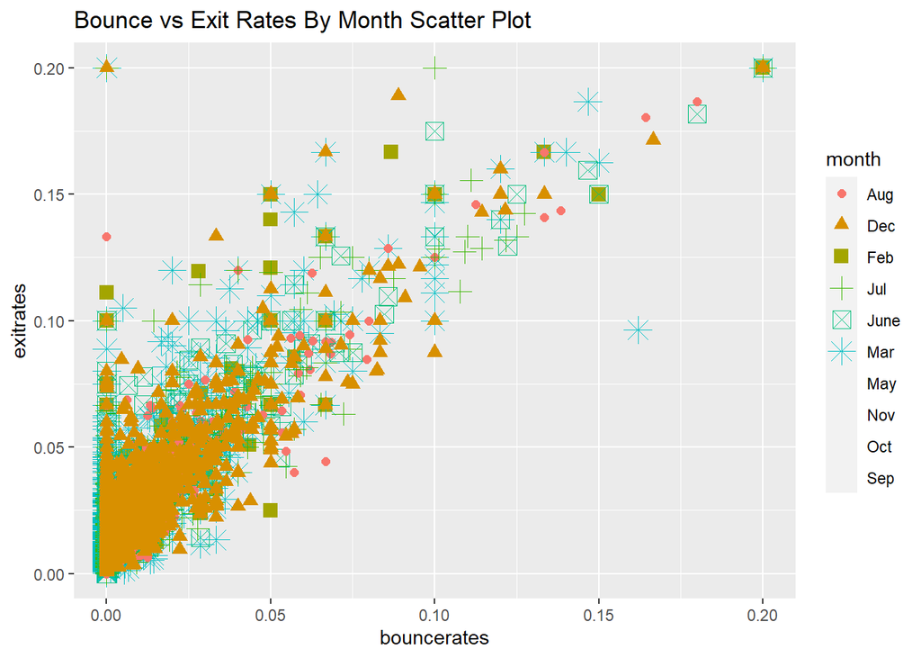

```r
# Scatter Plot using ggplots to find realtionship between two variables
# and their association with a categorical variable

ggplot(df, aes(x=bouncerates, y=exitrates, shape= month, color= month, size= month)) +
  geom_point()+
  labs(title = "Bounce vs Exit Rates By Month Scatter Plot")
```

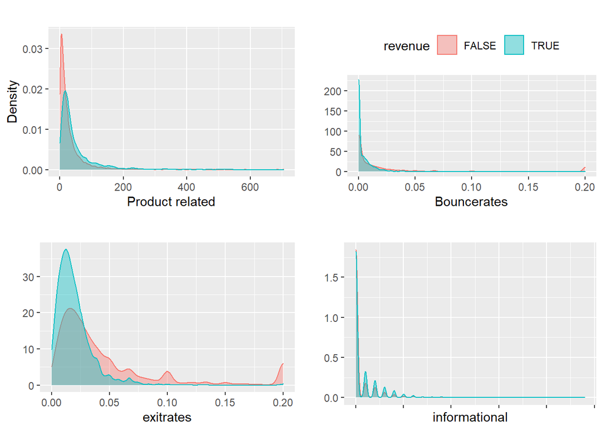

```r
#Checking the distribution of different variables in relation to revenue
options(repr.plot.width = 11, repr.plot.height = 5)
p1 = ggplot(df, aes(productrelated, col = revenue)) +
  geom_density(aes(fill = revenue), alpha = 0.4) +
  labs(x = 'Product related', y = 'Density', title = '') +
  theme(legend.position = 'none',
       plot.title = element_text(size = 12))

p2 = ggplot(df, aes(bouncerates, col = revenue)) +
  geom_density(aes(fill = revenue), alpha = 0.4) +
  labs(x = 'Bouncerates', y = '', title = '') +
  theme(legend.position = 'top')

p3 = ggplot(df, aes(exitrates, col = revenue)) +
  geom_density(aes(fill = revenue), alpha = 0.4) +
  labs(x = 'exitrates', y = '', title = '') +
  theme(legend.position = 'none',
       plot.title = element_text(size = 12))


p4 = ggplot(df, aes(informational, col = revenue)) +
  geom_density(aes(fill = revenue), alpha = 0.4) +
  labs(x = 'informational', y = '', title = '') +
  theme(legend.position = 'none',
       plot.title = element_text(size = 12))


ggarrange(p1, p2, p3, p4 + rremove("x.text"),
          ncol = 2, nrow = 2)
```

```r
install.packages("corrplot")
library(corrplot)
```

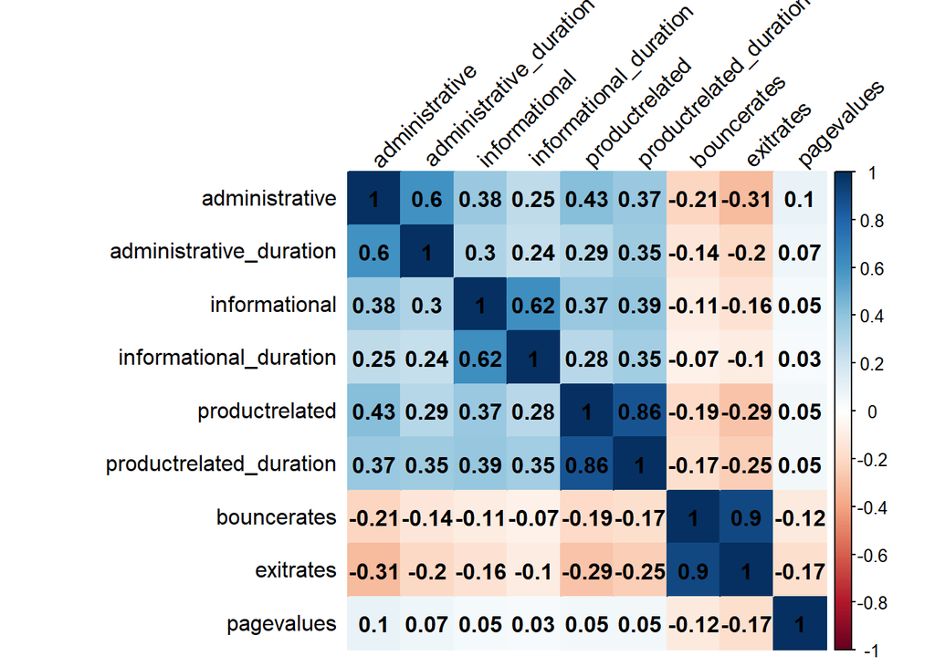

```r
#Get the correlation matrix
res = cor(nums)
#Plotting a correlation plot

corrplot(res, method="color",addCoef.col = "black",
         tl.col="black", tl.srt=45)
```

-there exists a strong positive relationship between a page and its respective duration for example Product Related page and Product Related Duration